# Étude d’impact d’un projet routier sur des Amphibiens

Auteur·rice

GOURBILLON Candys, DELANNOY Mathéo, LENQUETTE Anael, LAPORTE Paul

## 1 Introduction

Le jeu de données utilisé pour les analyses suivantes provient de diverses sources comprenant des données de Système d’Information Géographique (SIG), d’imagerie satellitaire ainsi que de relevés naturalistes (Łoboda, Żydelis, et Olszewski 2019).

Toutes ces données ont été réunies dans le cadre des Etudes d’Impact sur l’Environnement (EIE) pour deux projets routiers en Pologne et se concentrent sur un taxon bien particulier, les amphibiens. Plus précisément, le dataset associe des données environnementales liées aux routes à des données d’occurrence pour 7 espèces d’amphibiens. Ces 7 espèces sont : la grenouille verte (*Pelophylax* sp.), la grenouille brune/rousse (*Rana temporaria*), le crapaud commun (*Bufo bufo*), le crapaud sonneur (*Bombina spp.*), la rainette arboricole (*Hyla arborea*), le triton commun (*Lissotriton vulgaris*) et le triton crêté (*Triturus cristatus*). Concernant les données environnementales, elles se décomposent en 14 variables visant à caractériser les routes et leur association avec des zones humides proches. On peut citer entre autres : la surface des zones humides (SR), leur nombre (NR), leur distance minimale aux routes (RR) ou encore le type d’occupation du sol associé (SUR1/2/3) (Table 1).

L’inventaire a été réalisé à proximité de tronçons de deux autoroutes distinctes, l’A1 (Pyrzowice, Pologne) et la S52 (Bielsko-Biała, Pologne). Au total, 189 sites de reproduction ont été échantillonnés, 80 pour l’autoroute A1 et 109 pour l’autoroute S52. Le protocole a consisté en l’échantillonnage sur une bande de 500m autour du projet routier pendant le printemps 2010, de zones à présence supposée ou avérée d’amphibiens. Ainsi, le but est notamment de prédire la présence d’espèces d’amphibiens à proximité des zones humides et leur relation avec les projets routiers dans une optique de conservation.

Lors de cette étude, l’enjeu sera de relever les variables importantes et explicatives de la présence ou de l’absence des amphibiens et voir si celles-ci varient selon l’espèce. Pour cela, divers outils statistiques seront appliqués, allant des analyses multivariées (ACC) aux modèles linéaires généralisés (GLM).

Table 1: Description des variables environnementales

| Code | Description | Nature de la variable |
| --- | --- | --- |
| SR | Surface du réservoir d’eau (m²) | Numérique |
| NR | Nombre de réservoirs d’eau | Numérique |
| TR | Type de réservoir d’eau (prairies humides, vallées fluviales, rivières…) | Catégorielle |
| VR | Végétation au sein des réservoirs (absence, bandes étroites, aire envahie…) | Catégorielle |
| SUR1 | Première occupation du sol dominante | Catégorielle |
| SUR2 | Deuxième occupation du sol dominante | Catégorielle |
| SUR3 | Troisième occupation du sol dominante | Catégorielle |
| UR | Type d’usage de l’eau des réservoirs (économique, technologique, récréationnel…) | Catégorielle |
| FR | Importance de la pêche au sein des réservoirs | Catégorielle |
| OR | Pourcentage d’accès des réservoirs aux aires non développées | Numérique |
| RR | Distance minimale du réservoir aux routes | Ordinale |
| BR | Distance minimale du réservoir aux bâtiments | Ordinale |
| MR | État du réservoir (propre, légèrement pollué, lourdement pollué) | Catégorielle |
| CR | Type de berge du réservoir (naturelle, bétonnée) | Catégorielle |

### 1.1 Apprendre plus sur les espèces étudiées

Retrouvez ci-dessous les fiches synthétiques des espèces analysées dans cette étude. Choisissez une espèce dans la liste pour consulter sa description et sa photo.

**Choisissez une espèce :**

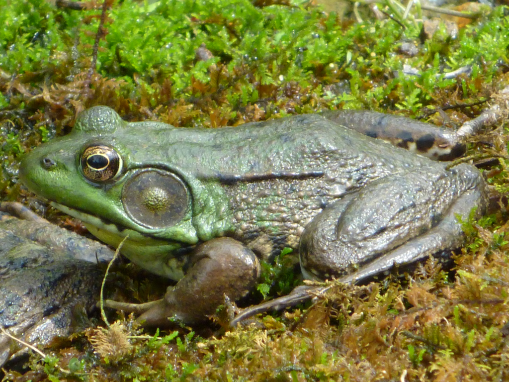

Par Contrabaroness — Travail personnel, [CC0](http://creativecommons.org/publicdomain/zero/1.0/deed.en), [Lien](https://commons.wikimedia.org/w/index.php?curid=15268023)

### Grenouille verte *(Pelophylax spp.)*

La grenouille verte, est un amphibien très aquatique mesurant de 8 à 12 cm. Son dos, vert à brun, est parsemé de taches sombres et souvent parcouru d’une fine ligne claire. On la rencontre toute l’année dans les plans d’eau ou à proximité, et les mâles chantent au printemps et en été. (Ligue pour la Protection des Oiseaux (LPO) 2026)

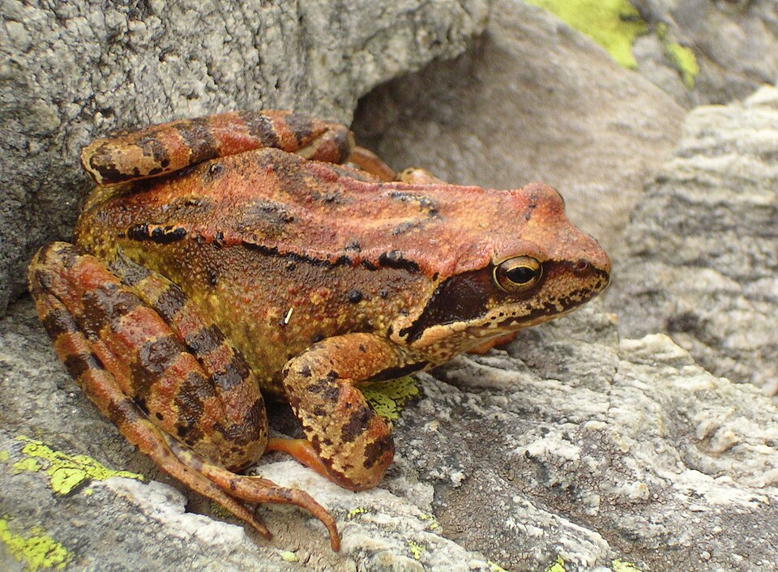

Par LivingShadow — Travail personnel, [CC0](http://creativecommons.org/publicdomain/zero/1.0/deed.en), [Lien](https://fr.wikipedia.org/wiki/Grenouille_rousse)

### Grenouille rousse *(Rana temporaria)*

La grenouille rousse est une espèce commune des milieux humides, des prairies et des forêts. Son corps est trapu et sa couleur varie du brun clair au brun foncé. Elle mesure généralement entre 5 et 10 cm. (Guillemin 1967)

[figure not shown]

Par [Heston_Benstead](https://commons.wikimedia.org/w/index.php?title=User:Heston_Benstead&action=edit&redlink=1) — Travail personnel, [CC0](http://creativecommons.org/publicdomain/zero/1.0/deed.en), [Lien](https://fr.wikipedia.org/wiki/Rana_dalmatina)

### Grenouille agile *(Rana dalmatina)*

Plus élancée que la grenouille rousse, la grenouille agile possède de longues pattes arrière qui lui permettent de réaliser de grands sauts. Elle fréquente surtout les bois et les lisières forestières (Guillemin 1967).

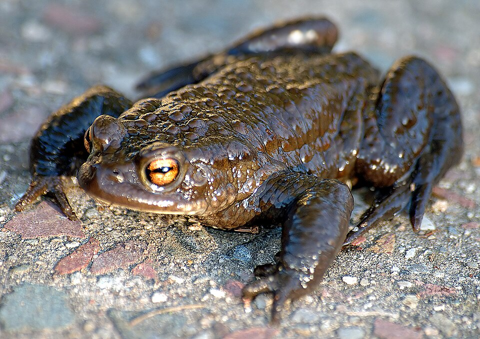

Par Aka — Travail personnel, [CC0](http://creativecommons.org/publicdomain/zero/1.0/deed.en), [Lien](https://fr.wikipedia.org/wiki/Crapaud_commun)

### Crapaud commun *(Bufo bufo)*

Le crapaud commun est un amphibien robuste et trapu, se nourrit principalement d’escargots, de vers de terre ou autres petits insectes. Il vit dans les zones humides (étangs, mares, sous-bois) (Woodland Trust, s. d.).

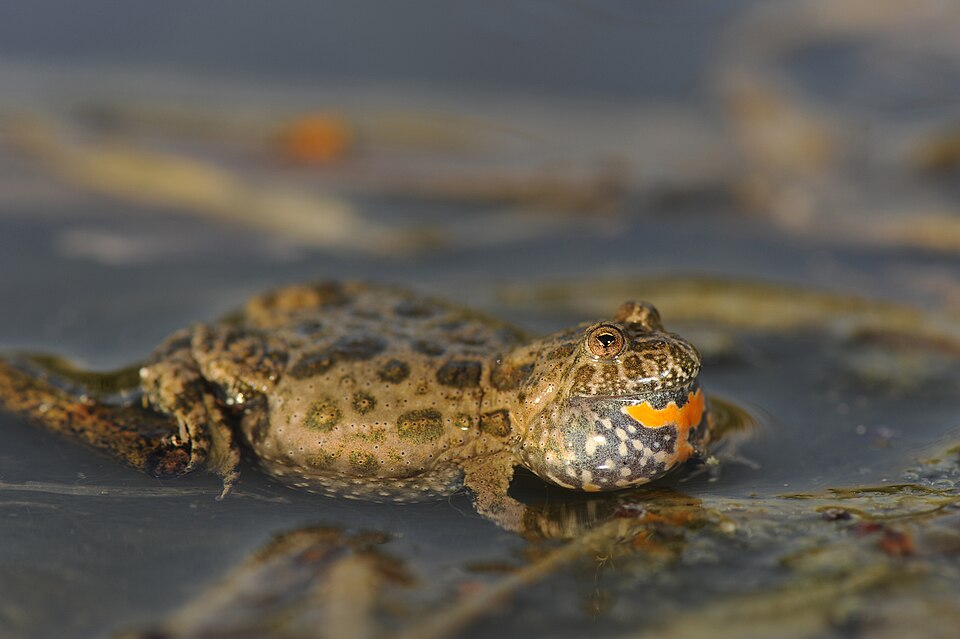

Par Benny Trapp — Travail personnel, [CC BY-SA 3.0](https://creativecommons.org/licenses/by-sa/3.0), [Lien](https://commons.wikimedia.org/w/index.php?curid=18794203)

### Crapaud sonneur *(Bombina spp.)*

Les Bombina spp., communément appelés les crapauds sonneurs, forment un genre de petits amphibiens de la famille des Bombinatoridae. Bien qu’on les appelle “crapauds”, ils possèdent des caractéristiques biologiques uniques qui les distinguent à la fois des vrais crapauds et des grenouilles (Hofman et al. 2007).

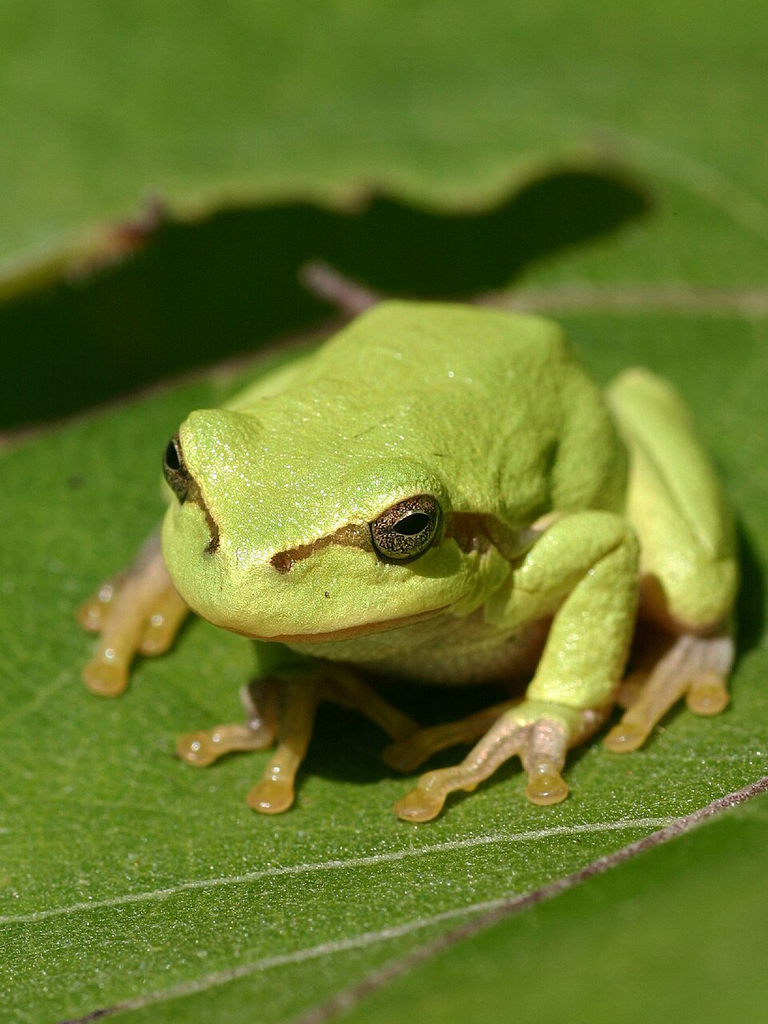

Par [Christoph Leeb](https://de.wikipedia.org/wiki/User:Christoph_Leeb) — Travail personnel, [CC BY-SA 3.0](http://creativecommons.org/licenses/by-sa/3.0/), [Lien](https://commons.wikimedia.org/w/index.php?curid=4347533)

### Rainette arboricole *(Hyla arborea)*

Hyla arborea, communément appelée la Rainette verte, est sans doute l’un des amphibiens les plus élégants d’Europe. Contrairement aux grenouilles vertes classiques (Pelophylax), elle appartient à la famille des Hylidae. Elle possède un mode de vie presque exclusivement arboricole (Andersen, Fog, et Damgaard 2004).

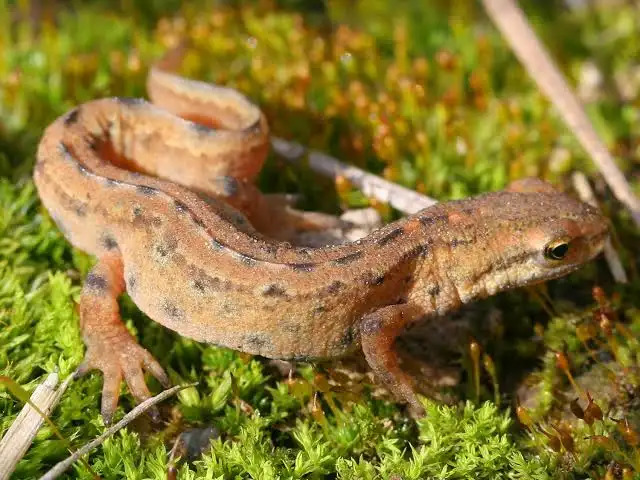

Par Contrabaroness — Travail personnel, [CC0](http://creativecommons.org/publicdomain/zero/1.0/deed.en), [Lien](https://commons.wikimedia.org/w/index.php?curid=15268023)

### Triton commun *(Lissotriton vulgaris)*

Le triton commun, Lissotriton vulgaris, est l’espèce de triton la plus répandue en Europe. Il occupe généralement des environnements stagnants et ensoleillés, de préférence sans poissons. Son alimentation varie selon qu’il soit en phase terrestre ou aquatique mais se constitue principalement de petits invertébrés (Skorinov et al. 2008).

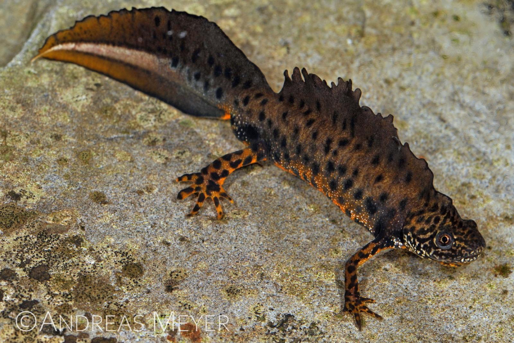

### Triton crêté *(Triturus cristatus)*

Triturus cristatus, de son nom commun le triton crêté, est une espèce de triton présente principalement dans le nord et l’est de l’Europe. A l’instar du triton commun, il possède une phase aquatique pendant le printemps dédiée à la reproduction et une phase terrestre le reste de l’année. Il est reconnaissable par sa grande taille (jusqu’à 18cm) et sa crête particulièrement développée chez le mâle pendant la période de reproduction (Arntzen et Teunis 1993).

## 2 Analyse de la diversité des communautés d’amphibiens

### 2.1 Diversité alpha : abondance et richesse spécifique

La diversité alpha décrit la diversité locale des communautés en termes de richesse spécifique (Xia et Sun 2023). Afin de comparer les communautés d’amphibiens associées aux autoroutes A1 et S52, une analyse de la diversité alpha a été réalisée à partir des données de présence-absence des espèces (Figure 1).

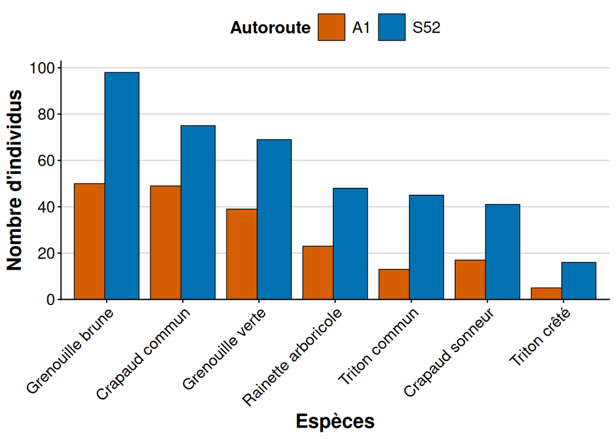

Figure 1: Abondance des différentes espèces d’amphibiens recensées le long des autoroutes A1 et S52.

La répartition des observations met en évidence des abondances plus élevées le long de l’autoroute S52 que sur l’autoroute A1 pour l’ensemble des espèces étudiées (Figure 1). Les grenouilles brunes constituent le groupe le plus fréquemment observé sur les deux sites, tandis que le triton crêté apparaît comme l’espèce la plus rare.

Malgré ces différences quantitatives, le classement relatif des espèces reste globalement similaire entre les deux autoroutes. Cette tendance suggère que les communautés présentes le long de l’A1 et de la S52 partagent une composition spécifique comparable, mais que les populations semblent plus abondantes sur la S52. Plusieurs facteurs peuvent expliquer ce résultat, notamment une qualité d’habitat plus favorable, une meilleure connectivité écologique (Clauzel et al. 2024) ou encore des différences dans les conditions d’échantillonnage (effort d’échantillonnage inégal, accessibilité des sites, observateurs différents). Des analyses statistiques complémentaires seraient toutefois nécessaires afin de déterminer si ces écarts sont significatifs.

### 2.2 Diversité bêta : similitude des communautés entre autoroutes

Si la diversité alpha permet de caractériser les communautés localement, elle ne renseigne pas sur le degré de similitude entre les assemblages observés. Afin d’évaluer les différences de composition spécifique entre les relevés effectués sur les deux autoroutes, une analyse de la diversité bêta (Chen et al. 2010) a été réalisée à partir des distances de Jaccard calculées sur les données de présence-absence (Figure 2).

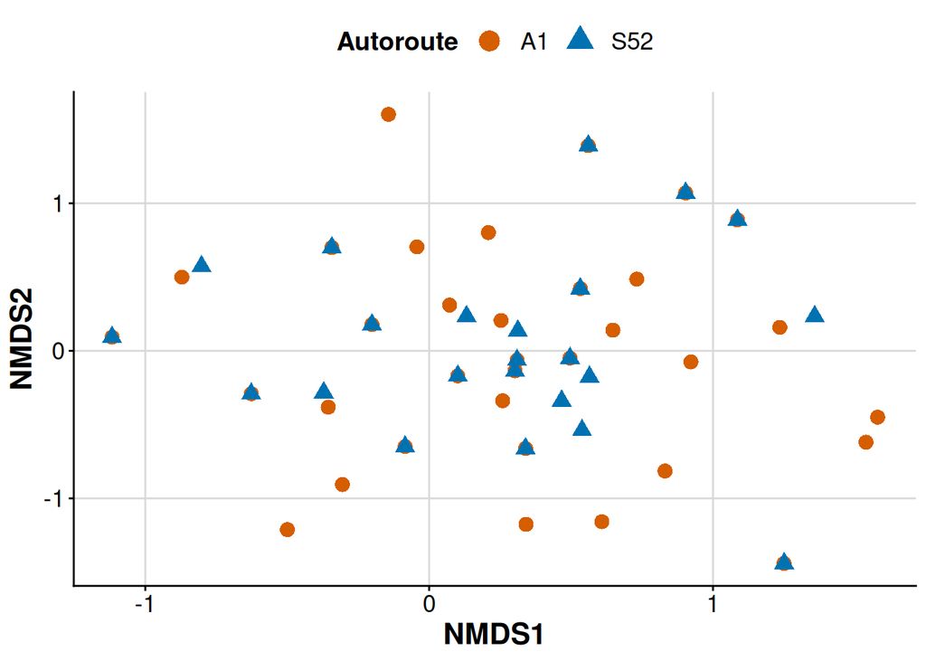

Figure 2: Ordination NMDS illustrant les différences de composition des communautés d’amphibiens recensées le long des autoroutes A1 et S52.

L’ordination NMDS (Souza 2025) obtenue à partir des distances de Jaccard montre un important chevauchement des relevés associés aux autoroutes A1 et S52 (Figure 2). Les points représentant les deux groupes ne forment pas de clusters distincts, ce qui suggère une forte similarité dans la composition des communautés d’amphibiens.

Ainsi, bien que la diversité alpha ait mis en évidence des différences d’abondance entre les deux autoroutes, la diversité bêta indique que les espèces présentes sont globalement les mêmes. Les variations observées semblent donc principalement liées aux effectifs des espèces plutôt qu’à une modification de la composition spécifique des communautés.

## 3 Préparation du jeu de donnée : corrélations des variables

Nous avions déjà exploré la diversité alpha et bêta de nos amis amphibiens, mais pour réaliser des modèles il est nécessaire de préparer correctement le jeu de données. Il faut alors d’abord vérifier que toutes les espèces sont bien représentées, puis écarter les sites où aucune espèce n’a été observée.

Selon les analyses réalisées, toutes les espèces sont présentes, avec des fréquences d’occurrence allant de 11.1% à 78.3% comme indiqué dans Table 2. En revanche, 6 sites ne comptent aucune observation : ils ont été donc supprimés, ce qui fait passer le jeu de données de 189 à 183 échantillons.

Table 2: Fréquence d’occurrence de chaque espèce (pourcentage de sites occupés).

| Espèce | Sites occupés (%) |
| --- | --- |
| Green.frogs | 57.1 |
| Brown.frogs | 78.3 |
| Common.toad | 65.6 |
| Fire.bellied.toad | 30.7 |
| Tree.frog | 37.6 |
| Common.newt | 30.7 |
| Great.crested.newt | 11.1 |

Nous avons ensuite vérifié les corrélations entre variables explicatives afin d’éviter la multicolinéarité dans les modèles : corrélation de Spearman (Spearman 1904) pour les variables numériques et ordinales, et V de Cramér (Cramér 1999) pour les variables catégorielles. Dans les deux cas, le seuil de redondance retenu est de $0,70$.

### 3.1 Corrélations et sélection des variables numériques

La matrice de corrélation de Spearman (Figure 3) met en évidence une seule paire dépassant le seuil $|r| > 0,70$ : RR–BR. Une seule de ces deux variables a donc été conservée (Table 3). Toutes les autres corrélations restent inférieures à $0,70$ en valeur absolue.

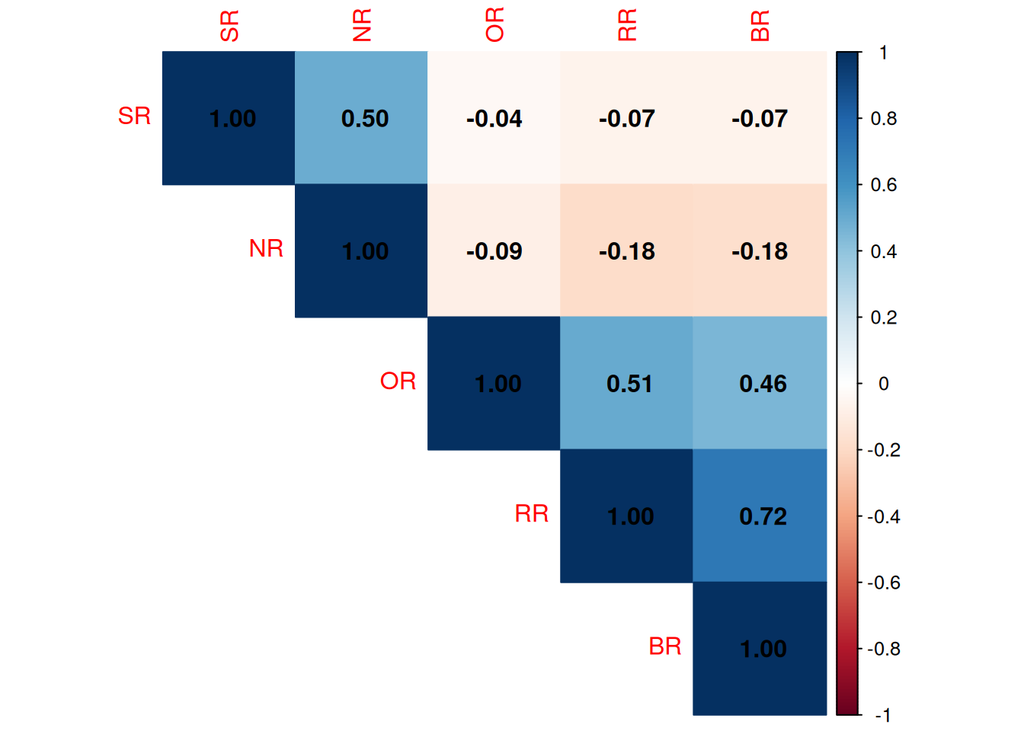

Figure 3: Matrice de corrélation de Spearman entre variables numériques.

Table 3: Variables corrélées (Spearman) et sélection des variables numériques. Sélection basée sur un seuil de corrélation r$> 0,70$ et une p-value $< 0,05$.

| Paire | r | p | Lien écologique | Conservée | Éliminée |
| --- | --- | --- | --- | --- | --- |
| **RR** (distance aux routes) et **BR** (distance aux bâtiments) | 0,72 | < 0,001 | Routes et constructions sont associées dans les zones urbanisées et périurbaines. | **RR** | **BR** |

### 3.2 Corrélations et sélection des variables catégorielles

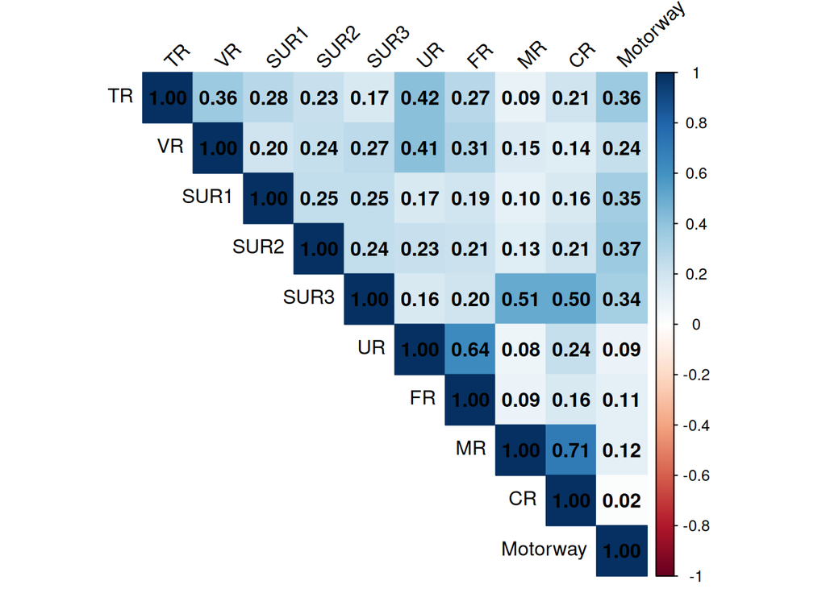

Figure 4: Matrice des V de Cramér entre variables catégorielles.

Table 4: Variables associées (V de Cramér) et sélection des variables catégorielles. Association mesurée par le V de Cramér (issu du test du $\chi^2$). Sélection basée sur un seuil $V > 0.70$ pour réduire la redondance entre variables catégorielles.

| Paire | r | Lien écologique | Conservée | Éliminée |
| --- | --- | --- | --- | --- |
| **MR** (état de maintenance) et **CR** (type de rive) | $0.71$ | Les rives artificialisées (béton) vont souvent de pair avec des milieux plus modifiés ou urbanisés, où l’entretien et les dépôts de déchets posent problème. | **CR** | **MR** |

Après cette sélection, les variables `BR` et `MR` ont été écartées pour la suite de l’analyse. Il reste donc `SR`, `NR`, `OR`, `FR` et `RR` pour les variables numériques et ordinales, et `TR`, `VR`, `SUR1`, `SUR2`, `SUR3`, `UR` et `CR` pour les variables catégorielles (Table 1).

## 4 Création des modèles pour étudier le jeu de données

### 4.1 Analyse multivariée à deux tableaux: structuration de la composition de la communauté d’amphibiens

Avec ce même jeu de données, on se demande **quelles variables structurent la composition et la diversité globale de la communauté d’amphibiens**. Pour cela, une approche appropriée est l’analyse multivariée.💡[^1]

Dans ce cas, ayant un jeu de données avec des informations sur la présence/absence des amphibiens ainsi que des variables catégorielles et numériques sur le contexte environnemental, une analyse canonique des correspondances (CCA) a été retenue 💡[^2].

#### 4.1.1 Construction du modèle

Le modèle canonique des correspondances a été construit à partir de l’ensemble des variables explicatives retenues (Équation 1).

$$\begin{aligned}
Y_{\text{amphibiens}} &\sim \text{SR} + \text{NR} + \text{OR} + \text{RR} \\
&\quad + \text{TR} + \text{VR} + \text{SUR}_{1} + \text{SUR}_{2} \\
&\quad + \text{SUR}_{3} + \text{UR} + \text{FR} + \text{CR} \\
&\quad + \text{Motorway}
\end{aligned}
\tag{1}$$

#### 4.1.2 Significativité du modèle

Ce modèle explique 27% de la variance totale de la composition en amphibiens. Parmi cette part expliquée, nos variables environnementales rendent compte de 39.4% de la variance sur le premier axe (CCA1) et de 18.8% sur le deuxième (CCA2).

Afin de valider la robustesse de ce modèle, un test ANOVA par permutation (999 permutations) a d’abord été réalisé pour évaluer si l’inertie contrainte par l’ensemble des variables était globalement significative. Ce test révèle que nos variables explicatives influencent significativement la composition en amphibiens (F = 1.2, p 0.009).

Ce résultat global ne précisant pas *quelles* variables sont réellement responsables de cet effet, un second test ANOVA a été réalisé, cette fois variable par variable (`by = 'term'`). Il montre que 2 variables sur l’ensemble testé sont significatives (p <= 0,05) : OR et TR. Ce même test effectué par marge (`by = 'margin'`) fournit un résultat distinct conservant uniquement TR. Ce sont donc ces variables qui seront retenues pour l’interprétation biologique détaillée ci-après ⚠️[^3].

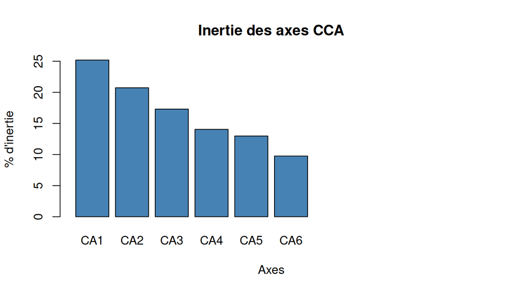

Figure 5: Histogramme des valeurs propres representants les inerties des premiers axes étudiés

#### 4.1.3 Interprétation graphique

Sur la base de ces deux axes retenus, nous avons représenté graphiquement les espèces et les variables explicatives significatives afin d’en interpréter les associations écologiques (Figure 6). Cette analyse reste descriptive et relative à la position des points d’ordination 💡[^4]. Pour une confirmation statistique de ces associations, voir la Section 4.2.

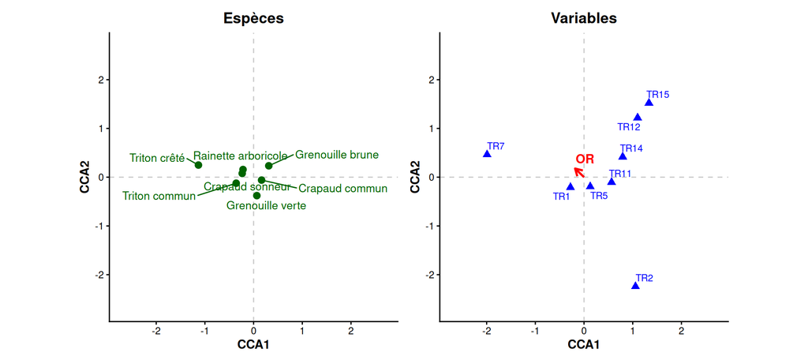

Figure 6: Graphiques d’ordination de la CCA (espèces et variables) sur les premiers axes.

Concernant la variable catégorique $TR$ (type de réservoir d’eau) :

- `TR7` → correspond aux tranchées ; associée au *Triton crêté*
- `TR15` → catégorie non identifiée ; associée aux *Grenouille brunes* et au *Crapaud commun*
- `TR2` → correspond aux réservoirs récemment formés, non soumis à une naturalisation ; aucune espèce associée, la catégorie étant trop éloignée des centroïdes
- `TR1`, `TR5`, `TR11` → correspondent respectivement à des réservoirs à caractère naturel, à des réservoirs hydrauliques techniques et à une catégorie non identifiée ; aucune association discutée, ces sous-catégories étant très proches de l’origine (contribution négligeable au modèle), leur position n’est donc pas interprétable de façon fiable

Concernant la variable numérique $OR$ (pourcentage d’accès des réservoirs aux aires non développées) : Nous pouvons observer que la qualité de projection n’est pas optimale, ce qui conduit à privilégier les résultats des modèles linéaires généralisés (Section 4.2).

#### 4.1.4 Conclusion CCA

En conclusion, les variables environnementales retenues structurent de façon significative la composition de la communauté d’amphibiens (F = 1.2, p = 0.009, bien que le modèle n’explique qu’une part modérée de la variance totale (27 %). Sur les deux premiers axes, deux tendances se dégagent : le triton crêté est associé aux tranchées (`TR7`), tandis que les *grenouilles brunes* et le *crapaud commun* sont associés à une catégorie non identifiée (`TR15`). Ces résultats restent descriptifs et, malheureusement, en raison de la mauvaise qualité de projection et des variables associées à des catégories non identifiées, ils constituent des hypothèses à confirmer espèce par espèce avec les modèles de la Section 4.2.

### 4.2 Modèle linéaire généralisé

#### 4.2.1 Analyse de l’influence des activités humaines sur la présence des amphibiens

Nous cherchons à savoir si la présence des amphibiens est influencée par les activités anthropiques. Pour tester cette hypothèse, nous utilisons des modèles linéaires généralisés (GLM) (Hastie et Pregibon 1992).

##### 4.2.1.1 Sélection de variables explicatives

On va d’abord chercher à identifier les variables explicatives correspondantes à l’influence humaine sur les populations d’Amphibiens.

Les variables retenues pour notre analyse des pressions anthropiques sont les suivantes : - FR : importance de la pêche au sein des réservoirs - RR : distance minimale du réservoir aux routes - BR : distance minimale du réservoir aux buildings - MR : état du réservoir (propre, légèrement pollué, lourdement pollué) - CR : type de berge du réservoir (naturelle, bétonnée)

Avec la matrice de corrélation (voir la Section 3), on peut observer que les paramètres RR et BR (Table 1) ont une corrélation absolue supérieure à 0.7, on supprime donc le paramètre BR. Pour vérifier la distribution des données et repérer d’éventuels effectifs trop faibles par modalité, un diagramme de proportions a été réalisé pour chaque variable.

**Répartition des variables explicatives**

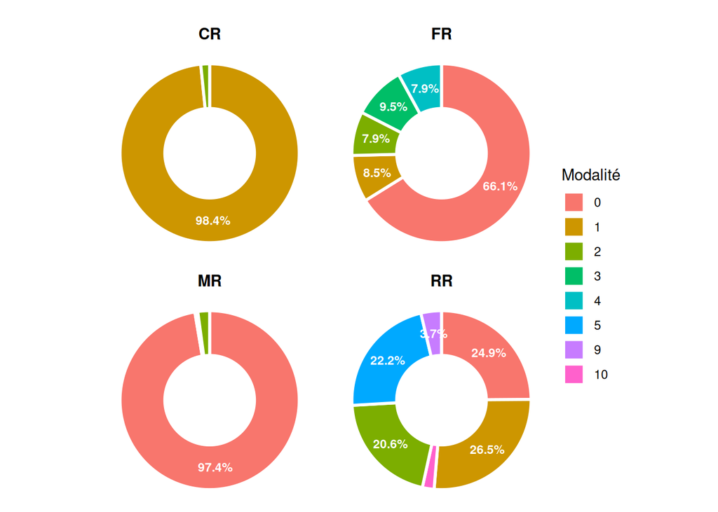

Figure 7: Répartition en pourcentages des variables explicatives.

On peut voir que les paramètres CR et MR (Figure 7) ont une modalité qui représente plus de 95% des valeurs, on les supprime alors.

##### 4.2.1.2 Analyse de la pêche et de la distance minimale des routes sur les amphibiens

On établit alors le modèle suivant :

$$\text{logit}(p_i) = \beta_0 + \beta_1 \text{FR}_i + \sum_{k} \beta_{\text{RR}_k} \cdot \mathbb{I}(\text{RR}_i = k) \tag{2}$$
où :

- $p_i$ correspond à la probabilité de présence sur le site $i$ ;
- $\beta_0$ est l’ordonnée à l’origine du modèle ;
- $\beta_1$ représente l’effet de l’intensité de la pêche ($\text{FR}$) sur le log-odds de présence ;
- $\beta_{\text{RR}_k}$ représente l’effet spécifique de la classe $k$ de la distance aux routes ($\text{RR}$) par rapport à la classe de référence ;
- $\mathbb{I}(\text{RR}_i = k)$ est une fonction indicatrice qui vaut 1 si l’observation $i$ appartient à la classe $k$ et 0 sinon ;
- $\text{FR}_i$ est la valeur observée de l’intensité de la pêche pour l’individu $i$.

**Résultats du modèle évaluant l’effet global de la pêche (FR) et des routes (RR) sur la présence des amphibiens**

Table 5: Effet global de la pêche et des routes sur la probabilité de présence des amphibiens (IC à 95%).

| term | estimate | std.error | statistic | p.value |
| --- | --- | --- | --- | --- |
| (Intercept) | -0.4472 | 0.1189 | -3.7607 | 0.0002 |
| FR | 0.1313 | 0.0419 | 3.1355 | 0.0017 |
| RR1 | 0.1210 | 0.1557 | 0.7768 | 0.4373 |
| RR2 | 0.0597 | 0.1662 | 0.3589 | 0.7197 |
| RR5 | 0.2694 | 0.1631 | 1.6517 | 0.0986 |
| RR9 | -0.0667 | 0.3149 | -0.2119 | 0.8322 |
| RR10 | 0.4472 | 0.3962 | 1.1287 | 0.2590 |

**Test d’ANOVA (type II) évaluant l’effet global de la pêche (FR) et de la distance aux routes (RR)**

Table 6: Test d’ANOVA (type II) évaluant l’effet global de la pêche (FR) et de la distance aux routes (RR)

|  | Df | Chisq | Pr(>Chisq) |
| --- | --- | --- | --- |
| FR | 1 | 9.8311 | 0.0017 |
| RR | 5 | 4.0883 | 0.5368 |

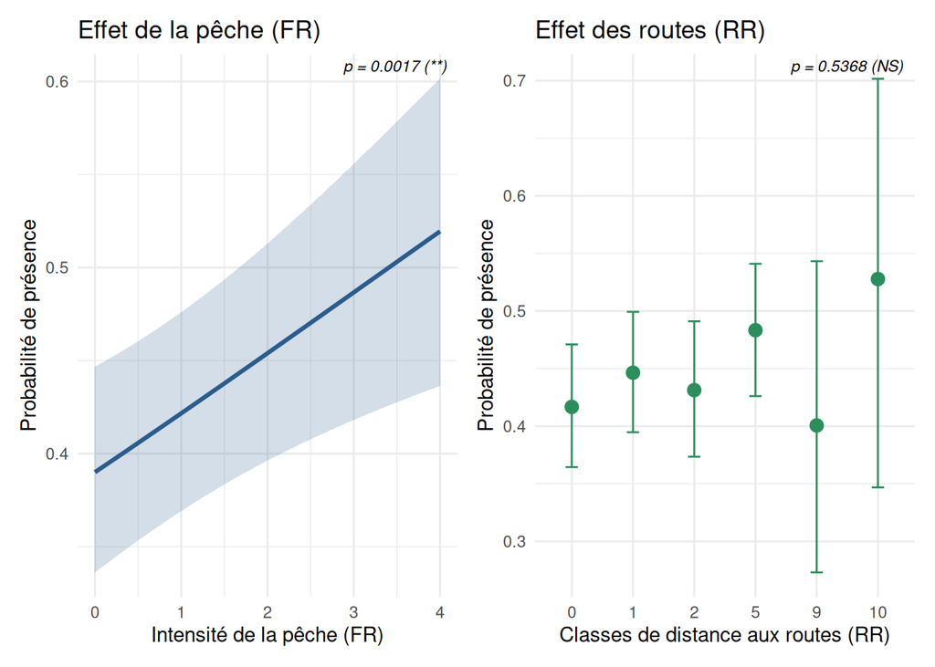

Figure 8: Effet global de la pêche et des routes sur la probabilité de présence des amphibiens (IC à 95%).

Le modèle logistique ajusté s’écrit :

$$\begin{aligned}
\text{logit}(p_i) = &-0.4472 + 0.1313 \times \text{FR}_i + 0.1210 \times \text{RR}_{1,i} + \\
&0.0597 \times \text{RR}_{2,i} + 0.2694 \times \text{RR}_{5,i} - \\
&0.0667 \times \text{RR}_{9,i} + 0.4472 \times \text{RR}_{10,i}
\end{aligned}
\tag{3}$$

En conclusion, le modèle ne met pas en évidence d’effet global significatif de la distance aux routes ($\text{RR}$) sur la probabilité de présence des amphibiens ($p = 0.5368$), les différents coefficients associés aux classes de distance s’avérant non significatifs au seuil de 5 % (Figure 8 , Table 5 & Table 6). En revanche, l’intensité de la pêche ($\text{FR}$) exerce une influence positive et significative sur leur présence ($p = 0.0017$) (Figure 8 , Table 5 & Table 6), suggérant que cette pression anthropique locale joue un rôle important dans la distribution des amphibiens.

#### 4.2.2 Analyse GLM : Quels facteurs influencent l’occurrence des amphibiens à proximité des routes selon l’espèce ?

Ce chapitre consiste à explorer davantage les liens entre les variables environnementales et l’occurrence des espèces d’amphibiens. Plus précisément, il tente de répondre à la question : Quels facteurs influencent l’occurrence des amphibiens à proximité des routes ? Pour y répondre, des GLM seront utilisés pour chaque espèce afin de voir si les variables concernées changent en fonction de celle-ci.

##### 4.2.2.1 Visualisation des données

Préalablement à l’analyse GLM des occurrences de chaque espèce, une visualisation des ratios de présence/absence selon les routes a été effectué. Les espèces d’amphibiens présentent des ratios très variables entre eux. Les espèces de tritons sont très peu observés comparativement aux autres espèces. Entre les routes, les ratios différent légèrement avec systématiquement plus de présence au sein de S52.

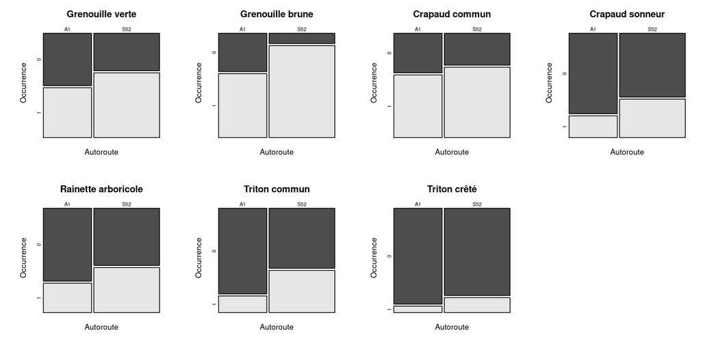

Figure 9: Diagrammes en mosaïque des proportions de présence (1) et d’absence (0) de chaque espèce d’amphibiens selon l’autoroute (A1 ou S52).

##### 4.2.2.2 Analyse GLM pour chaque espèce

###### 4.2.2.2.1 Modèle complet

Dans un premier temps, le modèle suivant est testé :

$$\begin{aligned}
\text{Species X} \sim &\text{SR} + \text{NR} + \text{TR} + \text{VR} + \\
&\text{SUR1} + \text{SUR2} + \text{SUR3} + \text{UR} + \\
&\text{OR} + \text{RR} + \text{CR}
\end{aligned}
\tag{4}$$

Pour la *grenouille rousse*, seul le pourcentage d’accès des zones humides aux aires non développées s’avère être une variable explicative de l’occurence. Lorsque l’accès aux zones non développées est important, on peut s’attendre à davantage de présence pour cette espèce. Cela s’avère cohérent avec le mode de vie de cette dernière qui est très terrestre et se disperse davantage que la *grenouille verte* (Guillemin 1967) (Ligue pour la Protection des Oiseaux (LPO) 2026). Ainsi, partant du principe que la route diminue l’accès à ces zones non développées, la *grenouille rouss*e est une autre victime potentiel du projet routier.

Enfin, en ce qui concerne le *crapaud commun*, seule la variable `TR` est significative avec un coefficient bêta de -0,088. Le type de zone humide a également un impact sur l’occurence de cette espèce. Dans la mesure où la route peut justement impacter le type de zone humide à proximité, le projet routier peut avoir un impact sur son occurence en ce sens.

Pour conclure sur ces premiers modèles, il existe bien une différence entre espèce des variables ayant un effet sur l’occurence et cette différence peut en partie s’expliquer par le mode de vie comme démontré pour le cas de la grenouille rousse.

Table 7: Résultats des GLM binomiaux (coefficients $\beta$ sur l’échelle logit) pour chaque espèce, avec l’ensemble des variables explicatives retenues. Seuils de significativité : * p < 0,05 ; ** p < 0,01 ; *** p < 0,001.

|  | Grenouille verte | Grenouille rousse | Crapaud commun | Crapaud sonneur | Rainette arboricole | Triton commun | Triton crêté |
| --- | --- | --- | --- | --- | --- | --- | --- |
| (Intercept) | 2.408 | 1.936 | 0.796 | 13.398 | 14.700 | 13.223 | 11.767 |
|  | (1.664) | (1.612) | (1.552) | (801.486) | (789.985) | (816.770) | (1300.547) |
| SR | 4.331 | 0.289 | -0.067 | 0.821 | 0.243 | 0.184 | 0.193 |
|  | (2.780) | (0.574) | (0.298) | (0.600) | (0.355) | (0.260) | (0.246) |
| NR | 0.358 | 0.050 | 0.236 | 0.038 | 0.239 | 0.036 | 0.037 |
|  | (0.381) | (0.280) | (0.276) | (0.241) | (0.231) | (0.227) | (0.281) |
| TR | -0.149*** | -0.005 | -0.088** | -0.097** | -0.088** | -0.151*** | -0.251* |
|  | (0.039) | (0.037) | (0.031) | (0.035) | (0.034) | (0.040) | (0.105) |
| VR | -0.113 | 0.105 | 0.016 | 0.016 | 0.268+ | 0.013 | 0.099 |
|  | (0.175) | (0.179) | (0.156) | (0.165) | (0.157) | (0.169) | (0.256) |
| SUR1 | 0.058 | 0.055 | 0.054 | -0.009 | -0.065 | 0.094+ | 0.032 |
|  | (0.057) | (0.060) | (0.051) | (0.052) | (0.052) | (0.053) | (0.079) |
| SUR2 | 0.044 | 0.036 | 0.043 | 0.044 | -0.002 | 0.029 | 0.049 |
|  | (0.055) | (0.057) | (0.049) | (0.051) | (0.049) | (0.052) | (0.076) |
| SUR3 | -0.156** | 0.034 | -0.058 | -0.021 | -0.018 | -0.019 | -0.111 |
|  | (0.058) | (0.058) | (0.052) | (0.053) | (0.050) | (0.054) | (0.082) |
| UR | 0.308 | -0.064 | 0.063 | -0.152 | -0.008 | -0.099 | -0.134 |
|  | (0.189) | (0.184) | (0.171) | (0.173) | (0.162) | (0.167) | (0.253) |
| OR | 0.031 | 0.397* | -0.065 | 0.464* | -0.138 | 0.493* | 0.684+ |
|  | (0.200) | (0.193) | (0.197) | (0.236) | (0.182) | (0.216) | (0.390) |
| RR | 0.200* | -0.005 | 0.025 | 0.017 | 0.073 | -0.013 | -0.127 |
|  | (0.084) | (0.086) | (0.072) | (0.073) | (0.070) | (0.077) | (0.125) |
| CR | -0.683 | -1.280 | 0.086 | -13.801 | -15.076 | -13.795 | -12.853 |
|  | (1.326) | (1.302) | (1.302) | (801.486) | (789.984) | (816.770) | (1300.547) |

+ p < 0.1, * p < 0.05, ** p < 0.01, *** p < 0.001

###### 4.2.2.2.2 Modèle réduit

Pour aller plus loin et à titre exploratoire, un modèle réduit a été testé reprenant les variables significatives des modèles valides précédents. L’objectif est de permettre une comparaison entre la totalité des espèces sur des modèles plus adaptés aux données. Le modèle est le suivant :
$$\text{Species X} \sim \text{TR} + \text{SUR3} + \text{OR} + \text{RR} \tag{5}$$

Les espèces n’ayant pas pu être traitée précédemment ont toutes les quatres la variables `TR` (Table 1) significative (Table 8). Les variations inter-espèces se trouvent chez le crapaud sonneur et le triton commun où la variable OR est signifcative. Dans ce cas, cette différence ne peut pas s’expliquer par une plus grande capacité de dispersion car ce n’est en réalité pas le cas. En revanche, ces deux espèces sont très sensibles au dessèchement et aux obstacles, et dépendent de micro-habitats contistituant des refuges (Skorinov et al. 2008). Ainsi, cette augmentation de l’occurence avec le pourcentage d’accès aux aires non dévellopées pourrait s’expliquer par cette sensibilité aux zones pas assez naturelles.

En conclusion, le projet routier pourrait avoir des conséquences différentes selon l’espèce. Certaines apparaissent comme éventuellement plus sensibles et d’autres moins mais la totalité pourrait être impactée.

Table 8: Résultats des GLM binomiaux du modèle réduit (TR + SUR3 + OR + RR) pour chaque espèce (coefficients $\beta$ sur l’échelle logit). Seuils de significativité : * p < 0,05 ; ** p < 0,01 ; *** p < 0,001.

|  | Grenouille verte | Grenouille rousse | Crapaud commun | Crapaud sonneur | Rainette arboricole | Triton commun | Triton crêté |
| --- | --- | --- | --- | --- | --- | --- | --- |
| (Intercept) | 1.829*** | 1.340** | 1.552*** | -0.187 | -0.025 | 0.032 | -0.429 |
|  | (0.450) | (0.454) | (0.420) | (0.400) | (0.377) | (0.406) | (0.560) |
| TR | -0.196*** | -0.006 | -0.100*** | -0.103** | -0.092** | -0.146*** | -0.252* |
|  | (0.035) | (0.034) | (0.029) | (0.034) | (0.031) | (0.038) | (0.106) |
| SUR3 | -0.154** | 0.007 | -0.067 | -0.043 | -0.045 | -0.036 | -0.136+ |
|  | (0.053) | (0.055) | (0.050) | (0.051) | (0.047) | (0.052) | (0.078) |
| OR | 0.061 | 0.408* | -0.106 | 0.523* | -0.010 | 0.459* | 0.665+ |
|  | (0.174) | (0.177) | (0.185) | (0.222) | (0.166) | (0.206) | (0.367) |
| RR | 0.155* | -0.011 | 0.013 | 0.013 | 0.083 | -0.026 | -0.131 |
|  | (0.078) | (0.081) | (0.068) | (0.071) | (0.067) | (0.075) | (0.126) |

+ p < 0.1, * p < 0.05, ** p < 0.01, *** p < 0.001

## 5 Conclusion

En somme, si l’étude de la diversité montre que les groupes d’espèces d’amphibiens restent en grande partie semblables entre les deux autoroutes, malgré des différences d’abondance locale, l’Analyse Canonique des Correspondances montre que les variables environnementales influencent vraiment ces communautés à travers des affinités précises. Les modèles complémentaires nuancent ensuite ces résultats en montrant que la distance aux routes n’a pas d’effet global important. Par contre, des pressions humaines locales jouent un rôle clé dans leur répartition. Au final, même si les effets de ces projets routiers varient selon la sensibilité de chaque espèce, tous les amphibiens risquent d’être touchés. Cela montre qu’il est essentiel d’utiliser une approche ciblée et basée sur plusieurs facteurs pour guider les mesures de protection. Enfin, ces travaux ouvrent la voie à des analyses de connectivité fonctionnelle et génétique pour évaluer l’efficacité réelle des aménagements de mitigation, tout en intégrant les impacts du changement climatique sur la dynamique des zones humides face aux défis de conservation à long terme.

## Les références

Andersen, Liselotte W., Kåre Fog, et Christian Damgaard. 2004. « Habitat Fragmentation Causes Bottlenecks and Inbreeding in the European Tree Frog (Hyla arborea) ». *Proceedings of the Royal Society B: Biological Sciences* 271 (1545): 1293‑1302. https://doi.org/10.1098/rspb.2004.2720.

Arntzen, J. W., et S. F. M. Teunis. 1993. « A Six Year Study on the Population Dynamics of the Crested Newt (Triturus cristatus) Following the Colonization of a Newly Created Pond ». *Herpetological Journal* 3: 99‑110.

Chen, Shengbin, Zhiyun Ouyang, Weihua Xu, et Yi Xiao. 2010. « A review of beta diversity studies ». *Biodiversity Science* 18 (4): 323‑35. https://doi.org/10.3724/SP.J.1003.2010.323.

Clauzel, Céline, Claire Godet, Simon Tarabon, Christophe Eggert, Gilles Vuidel, Marion Bailleul, et Claude Miaud. 2024. « From single to multiple habitat connectivity: The key role of composite ecological networks for amphibian conservation and habitat restoration ». *Biological Conservation*. https://doi.org/10.1016/j.biocon.2023.110604.

Cramér, Harald. 1999. *Mathematical Methods of Statistics*. Princeton Landmarks in Mathematics et Physics. Princeton, NJ: Princeton University Press.

Guillemin, Catherine. 1967. « Caryotypes de Rana temporaria (L.) et de Rana dalmatina (Bonaparte) ». *Chromosoma* 21: 189‑97. https://doi.org/10.1007/BF00343644.

Hastie, Trevor J., et Daryl Pregibon. 1992. « Generalized Linear Models ». In *Statistical Models in S*, édité par John M. Chambers et Trevor J. Hastie. Chapman; Hall. https://doi.org/10.1201/9780203738535-6.

Hofman, Sebastian, Christina Spolsky, Thomas Uzzell, Dan Cogălniceanu, Wiesław Babik, et Jacek M. Szymura. 2007. « Phylogeography of the Fire-Bellied Toads Bombina: Independent Pleistocene Histories Inferred from Mitochondrial Genomes ». *Molecular Ecology* 16 (11): 2301‑16. https://doi.org/10.1111/j.1365-294X.2007.03309.x.

Ligue pour la Protection des Oiseaux (LPO). 2026. « Grenouille verte ». https://www.lpo.fr/decouvrir-la-nature/fiches-especes/fiches-especes/amphibiens-reptiles/grenouille-verte.

Łoboda, Marcin, Grzegorz Żydelis, et Adam Olszewski. 2019. « Amphibian species occurrence dataset for road impact assessment in Poland ». UCI Machine Learning Repository. https://doi.org/10.24432/C5H90N.

Skorinov, Dmitry V., Valentina N. Kuranova, Leo J. Borkin, et Spartak N. Litvinchuk. 2008. « Distribution and Conservation Status of the Smooth Newt (Lissotriton vulgaris) in Western Siberia and Kazakhstan ». *Russian Journal of Herpetology* 15 (2): 157‑65. https://doi.org/10.30906/1026-2296-2008-15-2-157-165.

Souza, Tancredo. 2025. « Non-metric Multidimensional Scaling (NMDS) ». In *Advanced Statistical Analysis for Soil Scientists*. Springer Nature Switzerland. https://doi.org/10.1007/978-3-031-88161-9_6.

Spearman, Charles. 1904. « The Proof and Measurement of Association Between Two Things ». *The American Journal of Psychology* 15 (1): 72‑101. https://doi.org/10.2307/1412159.

Wikipedia contributors. 2026. « Multivariate statistics — Wikipedia, The Free Encyclopedia ». https://en.wikipedia.org/wiki/Multivariate_statistics.

Woodland Trust. s. d. « Common Toad (Bufo bufo) ». [woodlandtrust.org.uk](https://www.woodlandtrust.org.uk/trees-woods-and-wildlife/animals/reptiles-and-amphibians/common-toad/.

Xia, Yinglin, et Jun Sun. 2023. « Alpha Diversity ». In *Bioinformatic and Statistical Analysis of Microbiome Data*, 289‑333. Springer. https://doi.org/10.1007/978-3-031-21391-5_9.

## Notes de bas de page

[^1]: Les analyses multivariées permettent d’analyser simultanément de multiples variables afin de découvrir des modèles, des structures et des relations complexes qui ne peuvent être mis en évidence par l’analyse isolée de chaque variable (Wikipedia contributors (2026)).
[^2]: Cette méthode permet de contraindre l’ordination de la communauté d’amphibiens par un ensemble de variables explicatives, et ainsi d’identifier lesquelles structurent le plus la composition observée.
[^3]: Dans une analyse classique, seules les variables retenues par le test marginal (by = ‘margin’) devraient être conservées car ce test élimine les effets de colinéarité. Cependant, nous avons choisi de discuter également la seconde variable identifiée par by = ‘term’, car son effet global reste significatif et apporte un éclairage écologique complémentaire sur les facteurs structurant le milieu.
[^4]: Les variables catégoriques sont interprétées à partir de la distance entre le centroïde de chaque sous-catégorie et celui des espèces : plus les deux centroïdes sont proches, plus l’association écologique supposée entre l’espèce et cette modalité est forte. Les variables numériques, en revanche, sont représentées par un vecteur et doivent être interprétées comme un gradient : la position d’une espèce le long de ce vecteur indique son association aux valeurs faibles ou élevées de la variable, indépendamment de toute notion de distance.